# Risk Factor Analysis

## Outcome Variable

**Outcome Variable:** whz

## Predictor Variables

**Intervention Variable:** feducyrs

**Adjustment Set:**

- arm
- W_mage
- meducyrs
- hhwealth_quart
- W_mhtcm
- W_mwtkg
- W_mbmi
- W_gagebrth
- W_birthwt
- W_birthlen
- single
- delta_W_mage
- delta_meducyrs
- delta_hhwealth_quart
- delta_W_mhtcm
- delta_W_mwtkg
- delta_W_mbmi
- delta_W_gagebrth
- delta_W_birthwt
- delta_W_birthlen
- delta_single

## Stratifying Variables

The analysis was stratified on these variable(s):

- agecat
- studyid
- country

## Data Summary

| agecat | studyid | country | feducyrs | n_cell | n |
| --- | --- | --- | --- | --- | --- |
| Birth | ki0047075b-MAL-ED | BANGLADESH | High | 44 | 119 |
| Birth | ki0047075b-MAL-ED | BANGLADESH | Low | 33 | 119 |
| Birth | ki0047075b-MAL-ED | BANGLADESH | Medium | 42 | 119 |
| Birth | ki0047075b-MAL-ED | INDIA | High | 7 | 23 |
| Birth | ki0047075b-MAL-ED | INDIA | Low | 13 | 23 |
| Birth | ki0047075b-MAL-ED | INDIA | Medium | 3 | 23 |
| Birth | ki0047075b-MAL-ED | NEPAL | High | 3 | 9 |
| Birth | ki0047075b-MAL-ED | NEPAL | Low | 3 | 9 |
| Birth | ki0047075b-MAL-ED | NEPAL | Medium | 3 | 9 |
| Birth | ki0047075b-MAL-ED | PERU | High | 84 | 190 |
| Birth | ki0047075b-MAL-ED | PERU | Low | 56 | 190 |
| Birth | ki0047075b-MAL-ED | PERU | Medium | 50 | 190 |
| Birth | ki0047075b-MAL-ED | SOUTH AFRICA | High | 10 | 33 |
| Birth | ki0047075b-MAL-ED | SOUTH AFRICA | Low | 14 | 33 |
| Birth | ki0047075b-MAL-ED | SOUTH AFRICA | Medium | 9 | 33 |
| Birth | ki0047075b-MAL-ED | TANZANIA, UNITED REPUBLIC OF | High | 62 | 96 |
| Birth | ki0047075b-MAL-ED | TANZANIA, UNITED REPUBLIC OF | Low | 26 | 96 |
| Birth | ki0047075b-MAL-ED | TANZANIA, UNITED REPUBLIC OF | Medium | 8 | 96 |
| Birth | ki1000304b-SAS-CompFeed | INDIA | High | 270 | 1101 |
| Birth | ki1000304b-SAS-CompFeed | INDIA | Low | 476 | 1101 |
| Birth | ki1000304b-SAS-CompFeed | INDIA | Medium | 355 | 1101 |
| Birth | ki1017093b-PROVIDE | BANGLADESH | High | 161 | 532 |
| Birth | ki1017093b-PROVIDE | BANGLADESH | Low | 185 | 532 |
| Birth | ki1017093b-PROVIDE | BANGLADESH | Medium | 186 | 532 |
| Birth | ki1017093c-NIH-Crypto | BANGLADESH | High | 277 | 707 |
| Birth | ki1017093c-NIH-Crypto | BANGLADESH | Low | 229 | 707 |
| Birth | ki1017093c-NIH-Crypto | BANGLADESH | Medium | 201 | 707 |
| Birth | ki1113344-GMS-Nepal | NEPAL | High | 162 | 640 |
| Birth | ki1113344-GMS-Nepal | NEPAL | Low | 266 | 640 |
| Birth | ki1113344-GMS-Nepal | NEPAL | Medium | 212 | 640 |

[output cut: 135 more lines]

The following strata were considered:

- agecat: 24 months, studyid: ki0047075b-MAL-ED, country: BANGLADESH
- agecat: 24 months, studyid: ki0047075b-MAL-ED, country: INDIA
- agecat: 24 months, studyid: ki0047075b-MAL-ED, country: NEPAL
- agecat: 24 months, studyid: ki0047075b-MAL-ED, country: PERU
- agecat: 24 months, studyid: ki0047075b-MAL-ED, country: SOUTH AFRICA
- agecat: 24 months, studyid: ki0047075b-MAL-ED, country: TANZANIA, UNITED REPUBLIC OF
- agecat: 24 months, studyid: ki1017093b-PROVIDE, country: BANGLADESH
- agecat: 24 months, studyid: ki1017093c-NIH-Crypto, country: BANGLADESH
- agecat: 24 months, studyid: ki1066203-TanzaniaChild2, country: TANZANIA, UNITED REPUBLIC OF
- agecat: 24 months, studyid: ki1113344-GMS-Nepal, country: NEPAL
- agecat: 24 months, studyid: ki1119695-PROBIT, country: BELARUS
- agecat: 24 months, studyid: ki1126311-ZVITAMBO, country: ZIMBABWE
- agecat: 24 months, studyid: ki1135781-COHORTS, country: GUATEMALA
- agecat: 24 months, studyid: ki1135781-COHORTS, country: INDIA
- agecat: 24 months, studyid: ki1135781-COHORTS, country: PHILIPPINES
- agecat: 24 months, studyid: ki1148112-LCNI-5, country: MALAWI
- agecat: 24 months, studyid: kiGH5241-JiVitA-3, country: BANGLADESH
- agecat: 24 months, studyid: kiGH5241-JiVitA-4, country: BANGLADESH
- agecat: 6 months, studyid: ki0047075b-MAL-ED, country: BANGLADESH
- agecat: 6 months, studyid: ki0047075b-MAL-ED, country: INDIA
- agecat: 6 months, studyid: ki0047075b-MAL-ED, country: NEPAL
- agecat: 6 months, studyid: ki0047075b-MAL-ED, country: PERU
- agecat: 6 months, studyid: ki0047075b-MAL-ED, country: SOUTH AFRICA
- agecat: 6 months, studyid: ki0047075b-MAL-ED, country: TANZANIA, UNITED REPUBLIC OF
- agecat: 6 months, studyid: ki1000304b-SAS-CompFeed, country: INDIA
- agecat: 6 months, studyid: ki1000304b-SAS-FoodSuppl, country: INDIA
- agecat: 6 months, studyid: ki1017093b-PROVIDE, country: BANGLADESH
- agecat: 6 months, studyid: ki1017093c-NIH-Crypto, country: BANGLADESH
- agecat: 6 months, studyid: ki1066203-TanzaniaChild2, country: TANZANIA, UNITED REPUBLIC OF
- agecat: 6 months, studyid: ki1113344-GMS-Nepal, country: NEPAL
- agecat: 6 months, studyid: ki1119695-PROBIT, country: BELARUS
- agecat: 6 months, studyid: ki1126311-ZVITAMBO, country: ZIMBABWE
- agecat: 6 months, studyid: ki1135781-COHORTS, country: GUATEMALA
- agecat: 6 months, studyid: ki1135781-COHORTS, country: INDIA
- agecat: 6 months, studyid: ki1135781-COHORTS, country: PHILIPPINES
- agecat: 6 months, studyid: ki1148112-LCNI-5, country: MALAWI
- agecat: 6 months, studyid: kiGH5241-JiVitA-3, country: BANGLADESH
- agecat: 6 months, studyid: kiGH5241-JiVitA-4, country: BANGLADESH
- agecat: Birth, studyid: ki0047075b-MAL-ED, country: BANGLADESH
- agecat: Birth, studyid: ki0047075b-MAL-ED, country: INDIA
- agecat: Birth, studyid: ki0047075b-MAL-ED, country: NEPAL
- agecat: Birth, studyid: ki0047075b-MAL-ED, country: PERU
- agecat: Birth, studyid: ki0047075b-MAL-ED, country: SOUTH AFRICA
- agecat: Birth, studyid: ki0047075b-MAL-ED, country: TANZANIA, UNITED REPUBLIC OF
- agecat: Birth, studyid: ki1000304b-SAS-CompFeed, country: INDIA
- agecat: Birth, studyid: ki1017093b-PROVIDE, country: BANGLADESH
- agecat: Birth, studyid: ki1017093c-NIH-Crypto, country: BANGLADESH
- agecat: Birth, studyid: ki1113344-GMS-Nepal, country: NEPAL
- agecat: Birth, studyid: ki1119695-PROBIT, country: BELARUS
- agecat: Birth, studyid: ki1126311-ZVITAMBO, country: ZIMBABWE
- agecat: Birth, studyid: ki1135781-COHORTS, country: GUATEMALA
- agecat: Birth, studyid: ki1135781-COHORTS, country: INDIA
- agecat: Birth, studyid: ki1135781-COHORTS, country: PHILIPPINES
- agecat: Birth, studyid: kiGH5241-JiVitA-3, country: BANGLADESH
- agecat: Birth, studyid: kiGH5241-JiVitA-4, country: BANGLADESH

### Dropped Strata

Some strata were dropped due to rare outcomes:

- agecat: Birth, studyid: ki0047075b-MAL-ED, country: INDIA
- agecat: Birth, studyid: ki0047075b-MAL-ED, country: NEPAL
- agecat: 24 months, studyid: ki1066203-TanzaniaChild2, country: TANZANIA, UNITED REPUBLIC OF

## Methods Detail

We’re interested in the causal parameters $E[Y_a]$ for all values of $a \in \mathcal{A}$. These parameters represent the mean outcome if, possibly contrary to fact, we intervened to set all units to have $A=a$. Under the randomization and positivity assumptions, these are identified by the statistical parameters $\psi_a=E_W[E_{Y|A,W}(Y|A=a,W)]$. In addition, we’re interested in the mean of $Y$, $E[Y]$ under no intervention (the observed mean). We will estimate these parameters by using SuperLearner to fit the relevant likelihood factors – $E_{Y|A,W}(Y|A=a,W)$ and $p(A=a|W)$, and then updating our likelihood fit using a joint TMLE.

For unadjusted analyses ($W=\{\}$), initial likelihoods were estimated using Lrnr_glm to estimate the simple $E(Y|A)$ and Lrnr_mean to estimate $p(A)$. For adjusted analyses, a small library containing Lrnr_glmnet, Lrnr_xgboost, and Lrnr_mean was used.

Having estimated these parameters, we will then use the delta method to estimate relative risks and attributable risks relative to a prespecified baseline level of $A$.

# Results Detail

## Results Plots

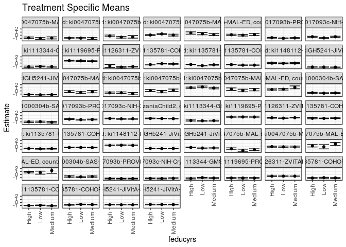

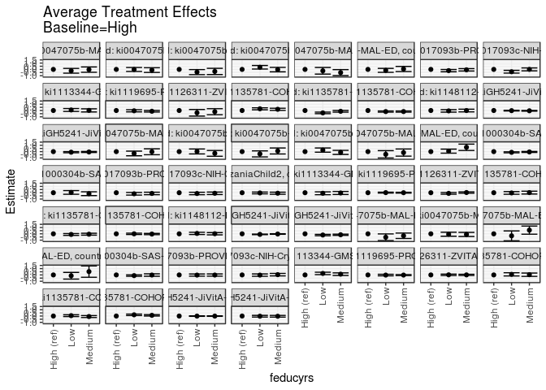

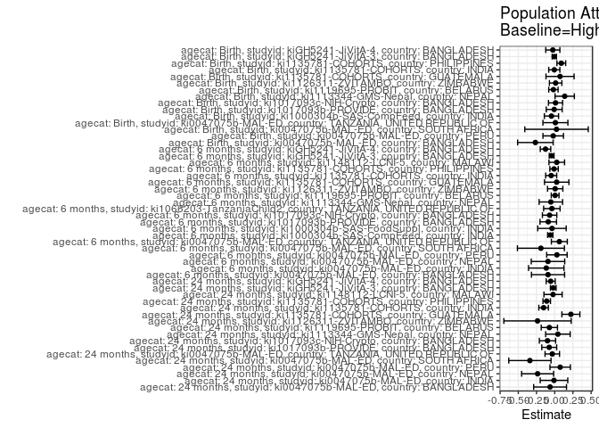

## Results Table

### Parameter: TSM

| agecat | studyid | country | intervention_level | baseline_level | estimate | ci_lower | ci_upper |
| --- | --- | --- | --- | --- | --- | --- | --- |
| Birth | ki0047075b-MAL-ED | BANGLADESH | High | NA | -0.6828813 | -0.9820639 | -0.3836987 |
| Birth | ki0047075b-MAL-ED | BANGLADESH | Low | NA | -1.2221663 | -1.6545802 | -0.7897524 |
| Birth | ki0047075b-MAL-ED | BANGLADESH | Medium | NA | -0.9883964 | -1.2956044 | -0.6811884 |
| Birth | ki0047075b-MAL-ED | PERU | High | NA | 0.0059203 | -0.1589760 | 0.1708165 |
| Birth | ki0047075b-MAL-ED | PERU | Low | NA | -0.0560841 | -0.3247702 | 0.2126021 |
| Birth | ki0047075b-MAL-ED | PERU | Medium | NA | -0.0900357 | -0.3707554 | 0.1906840 |
| Birth | ki0047075b-MAL-ED | SOUTH AFRICA | High | NA | 0.2810000 | -0.1017325 | 0.6637325 |
| Birth | ki0047075b-MAL-ED | SOUTH AFRICA | Low | NA | -0.0364286 | -0.7135146 | 0.6406575 |
| Birth | ki0047075b-MAL-ED | SOUTH AFRICA | Medium | NA | 0.8666667 | 0.3467047 | 1.3866286 |
| Birth | ki0047075b-MAL-ED | TANZANIA, UNITED REPUBLIC OF | High | NA | 0.7446774 | 0.5287317 | 0.9606232 |
| Birth | ki0047075b-MAL-ED | TANZANIA, UNITED REPUBLIC OF | Low | NA | 0.6161538 | 0.1324976 | 1.0998101 |
| Birth | ki0047075b-MAL-ED | TANZANIA, UNITED REPUBLIC OF | Medium | NA | 1.2775000 | 0.4059642 | 2.1490358 |
| Birth | ki1000304b-SAS-CompFeed | INDIA | High | NA | -0.6237173 | -0.8332871 | -0.4141475 |
| Birth | ki1000304b-SAS-CompFeed | INDIA | Low | NA | -0.7313861 | -0.9172795 | -0.5454928 |
| Birth | ki1000304b-SAS-CompFeed | INDIA | Medium | NA | -0.6396875 | -0.8334907 | -0.4458844 |
| Birth | ki1017093b-PROVIDE | BANGLADESH | High | NA | -1.2915032 | -1.4236191 | -1.1593872 |
| Birth | ki1017093b-PROVIDE | BANGLADESH | Low | NA | -1.3155151 | -1.4380717 | -1.1929585 |
| Birth | ki1017093b-PROVIDE | BANGLADESH | Medium | NA | -1.3080199 | -1.4341700 | -1.1818699 |
| Birth | ki1017093c-NIH-Crypto | BANGLADESH | High | NA | -1.2557029 | -1.3825322 | -1.1288736 |
| Birth | ki1017093c-NIH-Crypto | BANGLADESH | Low | NA | -1.2826365 | -1.4256638 | -1.1396093 |
| Birth | ki1017093c-NIH-Crypto | BANGLADESH | Medium | NA | -1.2126625 | -1.3694488 | -1.0558761 |
| Birth | ki1113344-GMS-Nepal | NEPAL | High | NA | -1.2534748 | -1.4113812 | -1.0955685 |
| Birth | ki1113344-GMS-Nepal | NEPAL | Low | NA | -1.0160239 | -1.1406692 | -0.8913785 |
| Birth | ki1113344-GMS-Nepal | NEPAL | Medium | NA | -1.1326533 | -1.2713060 | -0.9940005 |
| Birth | ki1119695-PROBIT | BELARUS | High | NA | -1.1218358 | -1.3197093 | -0.9239623 |
| Birth | ki1119695-PROBIT | BELARUS | Low | NA | -1.1440400 | -1.3948830 | -0.8931970 |
| Birth | ki1119695-PROBIT | BELARUS | Medium | NA | -1.1434758 | -1.3476849 | -0.9392668 |
| Birth | ki1126311-ZVITAMBO | ZIMBABWE | High | NA | -0.5222540 | -0.6113440 | -0.4331641 |
| Birth | ki1126311-ZVITAMBO | ZIMBABWE | Low | NA | -0.5056482 | -0.5701283 | -0.4411682 |
| Birth | ki1126311-ZVITAMBO | ZIMBABWE | Medium | NA | -0.5146821 | -0.5443808 | -0.4849834 |

[output cut: 126 more lines]

### Parameter: E(Y)

| agecat | studyid | country | intervention_level | baseline_level | estimate | ci_lower | ci_upper |
| --- | --- | --- | --- | --- | --- | --- | --- |
| Birth | ki0047075b-MAL-ED | BANGLADESH | NA | NA | -0.9483613 | -1.1437809 | -0.7529418 |
| Birth | ki0047075b-MAL-ED | PERU | NA | NA | -0.0145789 | -0.1426994 | 0.1135416 |
| Birth | ki0047075b-MAL-ED | SOUTH AFRICA | NA | NA | 0.3060606 | -0.0577506 | 0.6698718 |
| Birth | ki0047075b-MAL-ED | TANZANIA, UNITED REPUBLIC OF | NA | NA | 0.7542708 | 0.5468640 | 0.9616776 |
| Birth | ki1000304b-SAS-CompFeed | INDIA | NA | NA | -0.6685468 | -0.8459689 | -0.4911247 |
| Birth | ki1017093b-PROVIDE | BANGLADESH | NA | NA | -1.2984586 | -1.3752758 | -1.2216415 |
| Birth | ki1017093c-NIH-Crypto | BANGLADESH | NA | NA | -1.2441513 | -1.3281130 | -1.1601897 |
| Birth | ki1113344-GMS-Nepal | NEPAL | NA | NA | -1.1161562 | -1.2038617 | -1.0284508 |
| Birth | ki1119695-PROBIT | BELARUS | NA | NA | -1.1396625 | -1.3498047 | -0.9295204 |
| Birth | ki1126311-ZVITAMBO | ZIMBABWE | NA | NA | -0.5092691 | -0.5354330 | -0.4831051 |
| Birth | ki1135781-COHORTS | GUATEMALA | NA | NA | -1.0475905 | -1.1510656 | -0.9441155 |
| Birth | ki1135781-COHORTS | INDIA | NA | NA | -1.0020759 | -1.0646599 | -0.9394920 |
| Birth | ki1135781-COHORTS | PHILIPPINES | NA | NA | -0.7218585 | -0.7694262 | -0.6742908 |
| Birth | kiGH5241-JiVitA-3 | BANGLADESH | NA | NA | -0.7747631 | -0.7940385 | -0.7554876 |
| Birth | kiGH5241-JiVitA-4 | BANGLADESH | NA | NA | -0.6831985 | -0.7361386 | -0.6302583 |
| 6 months | ki0047075b-MAL-ED | BANGLADESH | NA | NA | -0.3007955 | -0.4778591 | -0.1237319 |
| 6 months | ki0047075b-MAL-ED | INDIA | NA | NA | -0.7272766 | -0.9000901 | -0.5544630 |
| 6 months | ki0047075b-MAL-ED | NEPAL | NA | NA | 0.0334035 | -0.1647857 | 0.2315927 |
| 6 months | ki0047075b-MAL-ED | PERU | NA | NA | 1.0860565 | 0.9516698 | 1.2204433 |
| 6 months | ki0047075b-MAL-ED | SOUTH AFRICA | NA | NA | 0.3834783 | 0.1440275 | 0.6229290 |
| 6 months | ki0047075b-MAL-ED | TANZANIA, UNITED REPUBLIC OF | NA | NA | 0.5336484 | 0.3899788 | 0.6773181 |
| 6 months | ki1000304b-SAS-CompFeed | INDIA | NA | NA | -0.6641059 | -0.8040033 | -0.5242086 |
| 6 months | ki1000304b-SAS-FoodSuppl | INDIA | NA | NA | -1.0121579 | -1.1280429 | -0.8962729 |
| 6 months | ki1017093b-PROVIDE | BANGLADESH | NA | NA | -0.1990907 | -0.2817968 | -0.1163845 |
| 6 months | ki1017093c-NIH-Crypto | BANGLADESH | NA | NA | 0.0297622 | -0.0491685 | 0.1086930 |
| 6 months | ki1066203-TanzaniaChild2 | TANZANIA, UNITED REPUBLIC OF | NA | NA | 0.0791782 | 0.0263777 | 0.1319787 |
| 6 months | ki1113344-GMS-Nepal | NEPAL | NA | NA | -0.6031912 | -0.6894381 | -0.5169444 |
| 6 months | ki1119695-PROBIT | BELARUS | NA | NA | 0.5786017 | 0.5191854 | 0.6380180 |
| 6 months | ki1126311-ZVITAMBO | ZIMBABWE | NA | NA | 0.3153847 | 0.2894045 | 0.3413649 |
| 6 months | ki1135781-COHORTS | GUATEMALA | NA | NA | 0.1987403 | 0.1250477 | 0.2724329 |
| 6 months | ki1135781-COHORTS | INDIA | NA | NA | -0.6502599 | -0.7103477 | -0.5901722 |
| 6 months | ki1135781-COHORTS | PHILIPPINES | NA | NA | -0.2839930 | -0.3263706 | -0.2416154 |
| 6 months | ki1148112-LCNI-5 | MALAWI | NA | NA | 0.4414163 | 0.3697939 | 0.5130386 |
| 6 months | kiGH5241-JiVitA-3 | BANGLADESH | NA | NA | -0.5904964 | -0.6106039 | -0.5703890 |
| 6 months | kiGH5241-JiVitA-4 | BANGLADESH | NA | NA | -0.3852207 | -0.4232704 | -0.3471709 |
| 24 months | ki0047075b-MAL-ED | BANGLADESH | NA | NA | -0.9042735 | -1.0737243 | -0.7348227 |
| 24 months | ki0047075b-MAL-ED | INDIA | NA | NA | -0.9451515 | -1.0860650 | -0.8042380 |
| 24 months | ki0047075b-MAL-ED | NEPAL | NA | NA | -0.4668132 | -0.6466833 | -0.2869431 |
| 24 months | ki0047075b-MAL-ED | PERU | NA | NA | 0.1321189 | -0.0027984 | 0.2670362 |
| 24 months | ki0047075b-MAL-ED | SOUTH AFRICA | NA | NA | 0.3583333 | 0.1644154 | 0.5522513 |
| 24 months | ki0047075b-MAL-ED | TANZANIA, UNITED REPUBLIC OF | NA | NA | 0.1084840 | -0.0300100 | 0.2469780 |
| 24 months | ki1017093b-PROVIDE | BANGLADESH | NA | NA | -0.8928670 | -0.9755153 | -0.8102187 |
| 24 months | ki1017093c-NIH-Crypto | BANGLADESH | NA | NA | -0.6103502 | -0.7050157 | -0.5156847 |
| 24 months | ki1113344-GMS-Nepal | NEPAL | NA | NA | -1.1331550 | -1.2220936 | -1.0442165 |
| 24 months | ki1119695-PROBIT | BELARUS | NA | NA | 0.6847249 | 0.5730773 | 0.7963725 |
| 24 months | ki1126311-ZVITAMBO | ZIMBABWE | NA | NA | -1.1889512 | -1.2920613 | -1.0858411 |
| 24 months | ki1135781-COHORTS | GUATEMALA | NA | NA | -0.2662176 | -0.3220630 | -0.2103721 |
| 24 months | ki1135781-COHORTS | INDIA | NA | NA | -0.6051533 | -0.6581071 | -0.5521995 |
| 24 months | ki1135781-COHORTS | PHILIPPINES | NA | NA | -0.6155714 | -0.6532287 | -0.5779140 |
| 24 months | ki1148112-LCNI-5 | MALAWI | NA | NA | -0.0443153 | -0.1269075 | 0.0382769 |
| 24 months | kiGH5241-JiVitA-3 | BANGLADESH | NA | NA | -1.2984354 | -1.3225016 | -1.2743692 |
| 24 months | kiGH5241-JiVitA-4 | BANGLADESH | NA | NA | -1.2222794 | -1.2547188 | -1.1898401 |

### Parameter: ATE

| agecat | studyid | country | intervention_level | baseline_level | estimate | ci_lower | ci_upper |
| --- | --- | --- | --- | --- | --- | --- | --- |
| Birth | ki0047075b-MAL-ED | BANGLADESH | High | High | 0.0000000 | 0.0000000 | 0.0000000 |
| Birth | ki0047075b-MAL-ED | BANGLADESH | Low | High | -0.5392850 | -1.0644995 | -0.0140705 |
| Birth | ki0047075b-MAL-ED | BANGLADESH | Medium | High | -0.3055151 | -0.7339493 | 0.1229191 |
| Birth | ki0047075b-MAL-ED | PERU | High | High | 0.0000000 | 0.0000000 | 0.0000000 |
| Birth | ki0047075b-MAL-ED | PERU | Low | High | -0.0620044 | -0.3784443 | 0.2544355 |
| Birth | ki0047075b-MAL-ED | PERU | Medium | High | -0.0959560 | -0.4214654 | 0.2295534 |
| Birth | ki0047075b-MAL-ED | SOUTH AFRICA | High | High | 0.0000000 | 0.0000000 | 0.0000000 |
| Birth | ki0047075b-MAL-ED | SOUTH AFRICA | Low | High | -0.3174286 | -1.0952008 | 0.4603437 |
| Birth | ki0047075b-MAL-ED | SOUTH AFRICA | Medium | High | 0.5856667 | -0.0599684 | 1.2313017 |
| Birth | ki0047075b-MAL-ED | TANZANIA, UNITED REPUBLIC OF | High | High | 0.0000000 | 0.0000000 | 0.0000000 |
| Birth | ki0047075b-MAL-ED | TANZANIA, UNITED REPUBLIC OF | Low | High | -0.1285236 | -0.6581988 | 0.4011517 |
| Birth | ki0047075b-MAL-ED | TANZANIA, UNITED REPUBLIC OF | Medium | High | 0.5328226 | -0.3650679 | 1.4307130 |
| Birth | ki1000304b-SAS-CompFeed | INDIA | High | High | 0.0000000 | 0.0000000 | 0.0000000 |
| Birth | ki1000304b-SAS-CompFeed | INDIA | Low | High | -0.1076689 | -0.2215239 | 0.0061862 |
| Birth | ki1000304b-SAS-CompFeed | INDIA | Medium | High | -0.0159703 | -0.2086670 | 0.1767265 |
| Birth | ki1017093b-PROVIDE | BANGLADESH | High | High | 0.0000000 | 0.0000000 | 0.0000000 |
| Birth | ki1017093b-PROVIDE | BANGLADESH | Low | High | -0.0240119 | -0.1987489 | 0.1507250 |
| Birth | ki1017093b-PROVIDE | BANGLADESH | Medium | High | -0.0165168 | -0.1935792 | 0.1605457 |
| Birth | ki1017093c-NIH-Crypto | BANGLADESH | High | High | 0.0000000 | 0.0000000 | 0.0000000 |
| Birth | ki1017093c-NIH-Crypto | BANGLADESH | Low | High | -0.0269336 | -0.2133830 | 0.1595157 |
| Birth | ki1017093c-NIH-Crypto | BANGLADESH | Medium | High | 0.0430404 | -0.1541728 | 0.2402537 |
| Birth | ki1113344-GMS-Nepal | NEPAL | High | High | 0.0000000 | 0.0000000 | 0.0000000 |
| Birth | ki1113344-GMS-Nepal | NEPAL | Low | High | 0.2374510 | 0.0448074 | 0.4300945 |
| Birth | ki1113344-GMS-Nepal | NEPAL | Medium | High | 0.1208216 | -0.0810522 | 0.3226953 |
| Birth | ki1119695-PROBIT | BELARUS | High | High | 0.0000000 | 0.0000000 | 0.0000000 |
| Birth | ki1119695-PROBIT | BELARUS | Low | High | -0.0222042 | -0.1456767 | 0.1012682 |
| Birth | ki1119695-PROBIT | BELARUS | Medium | High | -0.0216401 | -0.0971434 | 0.0538633 |
| Birth | ki1126311-ZVITAMBO | ZIMBABWE | High | High | 0.0000000 | 0.0000000 | 0.0000000 |
| Birth | ki1126311-ZVITAMBO | ZIMBABWE | Low | High | 0.0166058 | -0.0920593 | 0.1252709 |
| Birth | ki1126311-ZVITAMBO | ZIMBABWE | Medium | High | 0.0075719 | -0.0847629 | 0.0999067 |

[output cut: 126 more lines]

### Parameter: PAR

| agecat | studyid | country | intervention_level | baseline_level | estimate | ci_lower | ci_upper |
| --- | --- | --- | --- | --- | --- | --- | --- |
| Birth | ki0047075b-MAL-ED | BANGLADESH | High | NA | -0.2654800 | -0.5095360 | -0.0214241 |
| Birth | ki0047075b-MAL-ED | PERU | High | NA | -0.0204992 | -0.1612394 | 0.1202409 |
| Birth | ki0047075b-MAL-ED | SOUTH AFRICA | High | NA | 0.0250606 | -0.4109032 | 0.4610244 |
| Birth | ki0047075b-MAL-ED | TANZANIA, UNITED REPUBLIC OF | High | NA | 0.0095934 | -0.1619187 | 0.1811055 |
| Birth | ki1000304b-SAS-CompFeed | INDIA | High | NA | -0.0448295 | -0.1425737 | 0.0529147 |
| Birth | ki1017093b-PROVIDE | BANGLADESH | High | NA | -0.0069555 | -0.1161087 | 0.1021977 |
| Birth | ki1017093c-NIH-Crypto | BANGLADESH | High | NA | 0.0115515 | -0.0854614 | 0.1085645 |
| Birth | ki1113344-GMS-Nepal | NEPAL | High | NA | 0.1373186 | 0.0046955 | 0.2699417 |
| Birth | ki1119695-PROBIT | BELARUS | High | NA | -0.0178267 | -0.0820214 | 0.0463679 |
| Birth | ki1126311-ZVITAMBO | ZIMBABWE | High | NA | 0.0129850 | -0.0725284 | 0.0984983 |
| Birth | ki1135781-COHORTS | GUATEMALA | High | NA | 0.0732897 | -0.1196860 | 0.2662654 |
| Birth | ki1135781-COHORTS | INDIA | High | NA | -0.0055408 | -0.0820659 | 0.0709843 |
| Birth | ki1135781-COHORTS | PHILIPPINES | High | NA | 0.0903760 | 0.0302332 | 0.1505189 |
| Birth | kiGH5241-JiVitA-3 | BANGLADESH | High | NA | -0.0057029 | -0.0350038 | 0.0235980 |
| Birth | kiGH5241-JiVitA-4 | BANGLADESH | High | NA | -0.0257728 | -0.1226636 | 0.0711180 |
| 6 months | ki0047075b-MAL-ED | BANGLADESH | High | NA | -0.0916240 | -0.3193372 | 0.1360893 |
| 6 months | ki0047075b-MAL-ED | INDIA | High | NA | -0.1159816 | -0.3592306 | 0.1272674 |
| 6 months | ki0047075b-MAL-ED | NEPAL | High | NA | -0.0922767 | -0.3223349 | 0.1377815 |
| 6 months | ki0047075b-MAL-ED | PERU | High | NA | 0.0304515 | -0.1098228 | 0.1707259 |
| 6 months | ki0047075b-MAL-ED | SOUTH AFRICA | High | NA | -0.1895590 | -0.5124131 | 0.1332951 |
| 6 months | ki0047075b-MAL-ED | TANZANIA, UNITED REPUBLIC OF | High | NA | 0.0635466 | -0.0458781 | 0.1729713 |
| 6 months | ki1000304b-SAS-CompFeed | INDIA | High | NA | -0.0609018 | -0.0971817 | -0.0246220 |
| 6 months | ki1000304b-SAS-FoodSuppl | INDIA | High | NA | -0.0377001 | -0.2332271 | 0.1578269 |
| 6 months | ki1017093b-PROVIDE | BANGLADESH | High | NA | -0.0883121 | -0.2018114 | 0.0251872 |
| 6 months | ki1017093c-NIH-Crypto | BANGLADESH | High | NA | -0.0699475 | -0.1687942 | 0.0288993 |
| 6 months | ki1066203-TanzaniaChild2 | TANZANIA, UNITED REPUBLIC OF | High | NA | -0.0391945 | -0.1523194 | 0.0739304 |
| 6 months | ki1113344-GMS-Nepal | NEPAL | High | NA | -0.0532388 | -0.2142590 | 0.1077814 |
| 6 months | ki1119695-PROBIT | BELARUS | High | NA | 0.0059439 | -0.0472648 | 0.0591526 |
| 6 months | ki1126311-ZVITAMBO | ZIMBABWE | High | NA | 0.0065634 | -0.0983753 | 0.1115022 |
| 6 months | ki1135781-COHORTS | GUATEMALA | High | NA | 0.0273704 | -0.1400775 | 0.1948183 |
| 6 months | ki1135781-COHORTS | INDIA | High | NA | -0.0484986 | -0.1243368 | 0.0273396 |
| 6 months | ki1135781-COHORTS | PHILIPPINES | High | NA | -0.0089794 | -0.0666165 | 0.0486576 |
| 6 months | ki1148112-LCNI-5 | MALAWI | High | NA | 0.0283761 | -0.0788638 | 0.1356161 |
| 6 months | kiGH5241-JiVitA-3 | BANGLADESH | High | NA | -0.0424023 | -0.0748502 | -0.0099544 |
| 6 months | kiGH5241-JiVitA-4 | BANGLADESH | High | NA | -0.1263883 | -0.1983013 | -0.0544753 |
| 24 months | ki0047075b-MAL-ED | BANGLADESH | High | NA | -0.0634445 | -0.2889107 | 0.1620217 |
| 24 months | ki0047075b-MAL-ED | INDIA | High | NA | -0.0098614 | -0.1992507 | 0.1795280 |
| 24 months | ki0047075b-MAL-ED | NEPAL | High | NA | -0.2347607 | -0.4544034 | -0.0151181 |
| 24 months | ki0047075b-MAL-ED | PERU | High | NA | 0.0751132 | -0.0650365 | 0.2152630 |
| 24 months | ki0047075b-MAL-ED | SOUTH AFRICA | High | NA | -0.3408544 | -0.6311954 | -0.0505133 |
| 24 months | ki0047075b-MAL-ED | TANZANIA, UNITED REPUBLIC OF | High | NA | -0.0333300 | -0.1328076 | 0.0661476 |
| 24 months | ki1017093b-PROVIDE | BANGLADESH | High | NA | -0.0751444 | -0.1774820 | 0.0271932 |
| 24 months | ki1017093c-NIH-Crypto | BANGLADESH | High | NA | -0.0991851 | -0.2110291 | 0.0126589 |
| 24 months | ki1113344-GMS-Nepal | NEPAL | High | NA | 0.0439324 | -0.1244403 | 0.2123051 |
| 24 months | ki1119695-PROBIT | BELARUS | High | NA | -0.0737047 | -0.1852848 | 0.0378753 |
| 24 months | ki1126311-ZVITAMBO | ZIMBABWE | High | NA | -0.2357638 | -0.6983916 | 0.2268641 |
| 24 months | ki1135781-COHORTS | GUATEMALA | High | NA | 0.2223264 | 0.0988973 | 0.3457555 |
| 24 months | ki1135781-COHORTS | INDIA | High | NA | -0.1525891 | -0.2180066 | -0.0871717 |
| 24 months | ki1135781-COHORTS | PHILIPPINES | High | NA | -0.1097370 | -0.1611692 | -0.0583047 |
| 24 months | ki1148112-LCNI-5 | MALAWI | High | NA | -0.0228694 | -0.1477881 | 0.1020492 |
| 24 months | kiGH5241-JiVitA-3 | BANGLADESH | High | NA | -0.0199881 | -0.0588867 | 0.0189106 |
| 24 months | kiGH5241-JiVitA-4 | BANGLADESH | High | NA | -0.0550537 | -0.1169638 | 0.0068563 |